# Pitch or Approach?

Unpacking the count effect on exit velocity, 2026 Statcast data

Author

Jim Albert

Published

October 24, 2026

## The question

Hitters hit the ball softer when they are behind in the count. In 2026 the average hitter’s exit velocity on balls in play was about 1.2–1.4 mph lower in counts where he was behind (0-1, 0-2, 1-2, 2-2) than in neutral counts (0-0, 1-0, 1-1, 2-1, 3-2). The study *Hitter-Specific Count Effects on Exit Velocity* also found that hitters differ in how much they lose, and that the differences persist and are tied to how much each hitter eases off his swing.

A friend raised an important objection. Hitters don’t see the same pitches in every count:

- **Pitchers pitch differently** when they’re ahead: more breaking balls, more pitches off the plate.
- **Hitters swing differently** when they’re behind: they protect the plate and put pitches in play that they would take in other counts.
- **Different pitches are hit differently.** Four-seam fastballs in the zone are hit hardest, and chased breaking balls are hit weakly when they are hit at all.

So part of the drop in exit velocity when behind might be about **which pitches end up in play** rather than **how the hitter swings at them**. And hitters might differ in the first as much as in the second. A free swinger who chases a lot might put many poor pitches in play when behind.

This document explains, step by step, how the two sources were separated and what the separation shows. It is an expanded version of the section *Does the pitch explain it?* in the longer study.

```r
library(dplyr)
library(tidyr)
library(readr)
library(purrr)
library(ggplot2)
library(mgcv)
library(cmdstanr)
library(posterior)
library(knitr)

sc_dir     <- Sys.getenv("SC_DIR", "~/Library/CloudStorage/Dropbox/STATCAST/data")
sc_pattern <- Sys.getenv("SC_PATTERN", "statcast%d.csv")
pitch_file <- "pitch_data_2026.rds"     # saved extract (shared with the main study)
names_file <- "batter_names.rds"        # saved hitter names
min_bip    <- 100

theme_set(theme_minimal(base_size = 12))
blue <- "#2f6db5"; red <- "#d9534f"
f1 <- function(x) sprintf("%.1f", x)
f2 <- function(x) sprintf("%.2f", x)
pct <- function(x) sprintf("%.0f%%", 100 * x)
```

```r
if (file.exists(pitch_file)) {
  pitches <- readRDS(pitch_file)
} else {
  pitches <- read_csv(file.path(sc_dir, sprintf(sc_pattern, 2026)),
                      col_select = c(game_type, batter, balls, strikes,
                                     description, pitch_type, release_speed,
                                     pfx_x, pfx_z, plate_x, plate_z, sz_top,
                                     sz_bot, zone, stand, p_throws, launch_speed),
                      show_col_types = FALSE, guess_max = 100000) |>
    filter(game_type == "R") |>
    select(-game_type)
  saveRDS(pitches, pitch_file)
}

if (file.exists(names_file)) {
  people <- readRDS(names_file)
} else {
  people <- baseballr::chadwick_player_lu() |>
    as_tibble() |>
    filter(!is.na(key_mlbam)) |>
    transmute(batter = as.numeric(key_mlbam),
              name = trimws(paste(name_first, name_last))) |>
    distinct(batter, .keep_all = TRUE)
  saveRDS(people, names_file)
}

pitch_group <- function(pt) case_when(
  pt == "FF"                          ~ "Four-seam",
  pt %in% c("SI", "FC")               ~ "Sinker/cutter",
  pt %in% c("SL", "ST", "SV")         ~ "Slider/sweeper",
  pt %in% c("CU", "KC", "CS")         ~ "Curveball",
  pt %in% c("CH", "FS", "FO", "SC")   ~ "Changeup/splitter",
  TRUE                                ~ NA_character_)

bip <- pitches |>
  filter(startsWith(description, "hit_into_play"), !is.na(launch_speed)) |>
  mutate(cnt = paste0(balls, "-", strikes),
         situation = case_when(
           cnt %in% c("2-0", "3-0", "3-1")        ~ "Ahead",
           cnt %in% c("0-1", "0-2", "1-2", "2-2") ~ "Behind",
           TRUE                                   ~ "Neutral"),
         pgroup = pitch_group(pitch_type),
         # horizontal location and movement flipped for left-handed hitters,
         # so positive means "inside"; height scaled to the hitter's zone
         side = if_else(stand == "R", -1, 1),
         x_in = side * plate_x,
         z_rel = (plate_z - sz_bot) / (sz_top - sz_bot),
         hmov = side * pfx_x,
         same_hand = factor(stand == p_throws),
         # distance outside the zone (inches; negative = inside the zone)
         d_out = 12 * pmax(abs(plate_x) - 0.83,
                           pmax(-z_rel, z_rel - 1) * (sz_top - sz_bot)),
         in_zone = zone %in% 1:9) |>
  filter(situation != "Ahead", !is.na(pgroup), !is.na(release_speed),
         !is.na(pfx_x), !is.na(pfx_z), !is.na(plate_x), !is.na(plate_z),
         !is.na(sz_top)) |>
  mutate(pgroup = factor(pgroup),
         situation = factor(situation, levels = c("Neutral", "Behind")),
         eff = if_else(situation == "Neutral", 0.5, -0.5))

# hitters with enough balls in play in neutral and behind counts
qual <- count(bip, batter) |> filter(n >= min_bip) |> pull(batter)
bip <- filter(bip, batter %in% qual)
```

The data are the 106,224 balls in play in 2026 by the 395 hitters with at least 100 balls in play in neutral and behind counts. Counts where the hitter is ahead (2-0, 3-0, 3-1) are left out, as in the main study.

## Step 1: The count changes which pitches are put in play

Start with the balls in play themselves. How do the ones put in play when behind differ from the ones put in play in neutral counts?

```r
mix <- bip |>
  group_by(situation) |>
  summarise(`Balls in play` = format(n(), big.mark = ","),
            `In the zone` = pct(mean(in_zone)),
            `Outside: median inches off the plate` =
              f1(median(d_out[!in_zone & d_out > 0])),
            `Four-seam` = pct(mean(pgroup == "Four-seam")),
            `Sinker/cutter` = pct(mean(pgroup == "Sinker/cutter")),
            `Slider/sweeper` = pct(mean(pgroup == "Slider/sweeper")),
            `Curveball` = pct(mean(pgroup == "Curveball")),
            `Changeup/splitter` = pct(mean(pgroup == "Changeup/splitter")),
            .groups = "drop")
mix |>
  pivot_longer(-situation, names_to = " ") |>
  pivot_wider(names_from = situation) |>
  kable(format.args = list(big.mark = ","))
```

Table 1: Balls in play by count situation, 2026

|  | Neutral | Behind |
| --- | --- | --- |
| Balls in play | 58,469 | 47,755 |
| In the zone | 83% | 71% |
| Outside: median inches off the plate | 2.5 | 3.1 |
| Four-seam | 29% | 27% |
| Sinker/cutter | 34% | 20% |
| Slider/sweeper | 18% | 25% |
| Curveball | 5% | 9% |
| Changeup/splitter | 13% | 20% |

Two things change when the hitter falls behind:

- **More balls in play come on pitches outside the zone,** and those pitches are farther outside.
- **The mix shifts from fastballs to off-speed pitches.** Sinkers and cutters drop sharply, and sliders, curveballs and changeups rise.

The location change is the more important of the two, because exit velocity falls steadily as a pitch moves away from the heart of the zone:

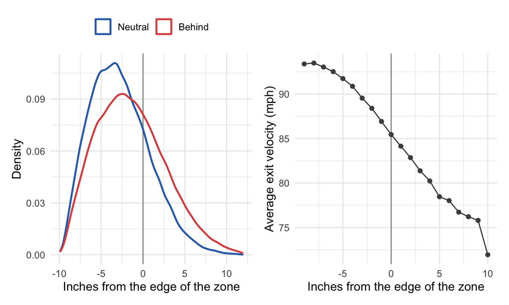

Figure 1: Left: where balls in play were pitched, relative to the edge of the strike zone (negative = inside the zone), by count. Right: average exit velocity by the same distance.

```r
p_left <- bip |>
  filter(between(d_out, -12, 12)) |>
  ggplot(aes(d_out, colour = situation)) +
  geom_vline(xintercept = 0, colour = "grey60") +
  geom_density(linewidth = 0.9) +
  scale_colour_manual(values = c(Neutral = blue, Behind = red), name = NULL) +
  labs(x = "Inches from the edge of the zone", y = "Density") +
  theme(legend.position = "top")
p_right <- bip |>
  filter(between(d_out, -12, 12)) |>
  mutate(bin = round(d_out)) |>
  group_by(bin) |>
  summarise(ev = mean(launch_speed), n = n()) |>
  filter(n >= 200) |>
  ggplot(aes(bin, ev)) +
  geom_vline(xintercept = 0, colour = "grey60") +
  geom_line(colour = "grey30") + geom_point(colour = "grey30") +
  labs(x = "Inches from the edge of the zone", y = "Average exit velocity (mph)")
if (requireNamespace("patchwork", quietly = TRUE)) {
  patchwork::wrap_plots(p_left, p_right)
} else {
  print(p_left); print(p_right)
}
```

So the balls in play when behind are, on average, harder pitches to hit hard. Some of the drop in exit velocity has nothing to do with how the hitter swings.

The pitch part blends two decisions that the data can’t fully separate:

- **The pitcher’s decision** to throw more pitches off the plate when ahead.
- **The hitter’s decision** to swing at, and put in play, pitches he would take in other counts.

Both are about which pitches end up in play.

## Step 2: An expected exit velocity for every ball in play

To separate *which pitches* from *how they were hit*, each ball in play gets an **expected exit velocity**: how hard an average 2026 hitter hits that pitch, in that location, whatever the count.

The expected value comes from a generalized additive model fit with `mgcv::bam` to all the balls in play above. For ball in play $i$,

$$E(\text{EV}_i) = \mu_{g} + \gamma\,\text{same}_i + f_{g}(x_i, z_i) +
s_1(\text{velo}_i) + s_2(\text{hmov}_i) + s_3(\text{vmov}_i),$$

where:

- $g$ is the pitch group (four-seam, sinker/cutter, slider/sweeper, curveball, changeup/splitter);
- $\text{same}_i$ indicates a pitcher and hitter on the same side;
- $f_g(x, z)$ is a smooth surface in pitch location for each pitch group, with $x$ measured toward the hitter (inside is positive) and $z$ scaled to the hitter’s own zone (0 = bottom, 1 = top);
- $s_1, s_2, s_3$ are smooth functions of velocity and of horizontal and vertical movement.

**The count is deliberately left out.** The model describes the pitch, not the situation.

```r
ev_fit <- bam(launch_speed ~ pgroup + same_hand +
                te(x_in, z_rel, by = pgroup, k = c(6, 6)) +
                s(release_speed, k = 6) + s(hmov, k = 6) + s(pfx_z, k = 6),
              data = bip, discrete = TRUE, nthreads = 4)
bip <- bip |>
  mutate(ev_exp = as.numeric(predict(ev_fit, newdata = bip)),
         ev_res = launch_speed - ev_exp)
```

The model explains about 20% of the variance of exit velocity on individual balls in play. That might sound low, but most of the variation comes from how squarely the ball is struck, which no pitch characteristic can predict.

The fitted location surfaces show what the model has learned. Here are two pitch groups, with the strike zone outlined:

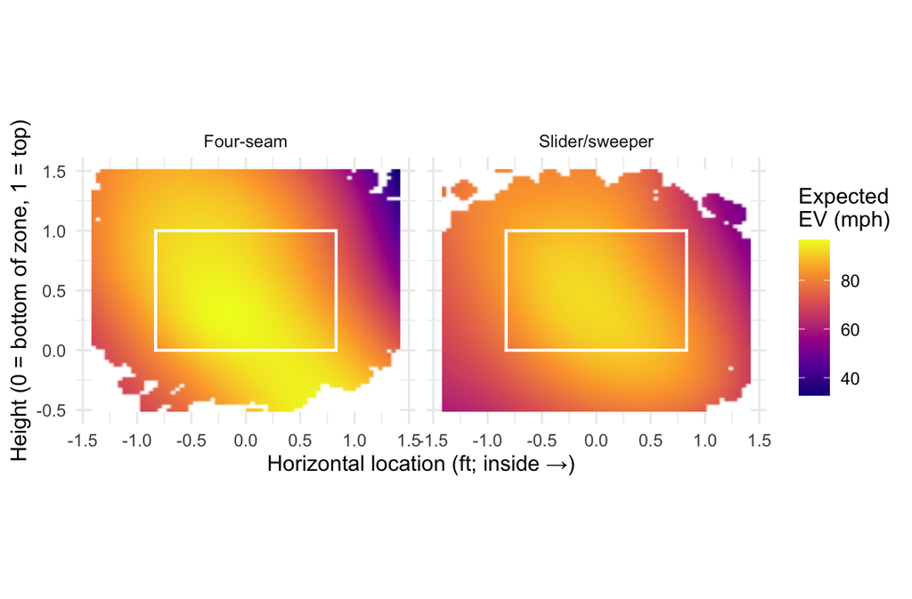

Figure 2: Expected exit velocity by pitch location for four-seam fastballs and sliders/sweepers (at typical velocity and movement for each), shown only where balls in play are common. The horizontal axis runs from the outside edge of the plate (left) to the inside edge (right) for both left- and right-handed hitters. The box is the strike zone.

```r
grid <- expand_grid(x_in = seq(-1.4, 1.4, length.out = 70),
                    z_rel = seq(-0.5, 1.5, length.out = 70),
                    pgroup = factor(c("Four-seam", "Slider/sweeper"),
                                    levels = levels(bip$pgroup))) |>
  left_join(bip |> group_by(pgroup) |>
              summarise(release_speed = median(release_speed),
                        hmov = median(hmov), pfx_z = median(pfx_z)),
            by = "pgroup") |>
  mutate(same_hand = factor(FALSE, levels = levels(bip$same_hand)))
grid$ev <- as.numeric(predict(ev_fit, newdata = grid))
# blank out locations far from any ball in play of that pitch group, where the
# surface would only be extrapolating
grid <- grid |>
  group_by(pgroup) |>
  group_modify(function(g, key) {
    obs <- filter(bip, pgroup == key$pgroup)
    g$ev[exclude.too.far(g$x_in, g$z_rel, obs$x_in, obs$z_rel, dist = 0.04)] <- NA
    g
  }) |>
  ungroup()
ggplot(grid, aes(x_in, z_rel, fill = ev)) +
  geom_raster(interpolate = TRUE) +
  annotate("rect", xmin = -0.83, xmax = 0.83, ymin = 0, ymax = 1,
           fill = NA, colour = "white", linewidth = 0.8) +
  facet_wrap(~ pgroup) +
  scale_fill_viridis_c(name = "Expected\nEV (mph)", option = "C", na.value = "white") +
  coord_fixed(ratio = 1.1) +
  labs(x = "Horizontal location (ft; inside →)",
       y = "Height (0 = bottom of zone, 1 = top)")
```

A quick check that the expected values are on target: grouping balls in play by distance from the zone, the average expected exit velocity tracks the average actual exit velocity closely in every group.

```r
bip |>
  mutate(Distance = cut(d_out, c(-Inf, -6, -3, 0, 3, 6, Inf),
                        labels = c("> 6 in inside", "3–6 in inside", "0–3 in inside",
                                   "0–3 in outside", "3–6 in outside", "> 6 in outside"))) |>
  group_by(Distance) |>
  summarise(`Balls in play` = n(), `Actual EV` = f1(mean(launch_speed)),
            `Expected EV` = f1(mean(ev_exp))) |>
  kable(format.args = list(big.mark = ","))
```

Table 2: Actual versus expected exit velocity by distance from the edge of the zone

| Distance | Balls in play | Actual EV | Expected EV |
| --- | --- | --- | --- |
| > 6 in inside | 17,700 | 93.1 | 93.2 |
| 3–6 in inside | 30,622 | 91.2 | 91.1 |
| 0–3 in inside | 28,860 | 87.7 | 87.7 |
| 0–3 in outside | 18,018 | 83.6 | 83.7 |
| 3–6 in outside | 7,783 | 79.8 | 79.9 |
| > 6 in outside | 3,241 | 75.7 | 75.5 |

## Step 3: Splitting the count effect

With an expected value for each ball in play, every exit velocity splits into two pieces:

$$\underbrace{\text{EV}_i}_{\text{actual}} =
\underbrace{\widehat{\text{EV}}_i}_{\text{expected (the pitch)}} +
\underbrace{(\text{EV}_i - \widehat{\text{EV}}_i)}_{\text{residual (the hitter's contact)}} .$$

Averaging over neutral counts and over behind counts, and taking the difference, splits the count effect the same way:

- the **pitch part** is how much the *expected* exit velocity drops when behind, which is about the pitches put in play; and
- the **approach part** is how much the *residual* drops, which is about how hard those pitches were hit compared with an average hitter.

The two parts add up exactly to the total.

```r
lg <- bip |>
  group_by(situation) |>
  summarise(Actual = mean(launch_speed), Expected = mean(ev_exp),
            Residual = mean(ev_res), .groups = "drop")
gap <- lg |> summarise(across(c(Actual, Expected, Residual), ~ .x[1] - .x[2])) |>
  mutate(situation = "Neutral minus behind")
bind_rows(lg |> mutate(situation = as.character(situation)), gap) |>
  transmute(` ` = situation, `Actual EV` = f2(Actual),
            `Expected EV (pitch)` = f2(Expected),
            `Residual (approach)` = f2(Residual)) |>
  kable()
```

Table 3: League averages, 2026: actual, expected and residual exit velocity by count, and the split of the neutral-minus-behind gap

|  | Actual EV | Expected EV (pitch) | Residual (approach) |
| --- | --- | --- | --- |
| Neutral | 88.62 | 88.73 | -0.11 |
| Behind | 87.19 | 87.05 | 0.14 |
| Neutral minus behind | 1.42 | 1.68 | -0.25 |

**The result is striking.** The pitch part, 1.68 mph, is *larger* than the whole 1.42 mph gap. The approach part is slightly negative, -0.25 mph. Taken at face value, a hitter who is behind puts worse pitches in play, but hits those pitches, if anything, a little harder than an average hitter would in another count.

Breaking the balls in play into those inside and outside the zone shows where the negative approach part comes from:

```r
zone_split |>
  transmute(Region, Count = situation, `Balls in play` = n,
            `Actual EV` = f1(Actual), `Expected EV` = f1(Expected),
            Residual = f2(Residual)) |>
  kable(format.args = list(big.mark = ","))
```

Table 4: Actual, expected and residual exit velocity by location and count, 2026

| Region | Count | Balls in play | Actual EV | Expected EV | Residual |
| --- | --- | --- | --- | --- | --- |
| In the zone | Neutral | 48,704 | 90.4 | 90.4 | 0.05 |
| In the zone | Behind | 34,017 | 89.8 | 89.8 | -0.00 |
| Outside the zone | Neutral | 9,765 | 79.5 | 80.5 | -0.94 |
| Outside the zone | Behind | 13,738 | 80.8 | 80.3 | 0.49 |

- **In the zone:** balls in play when behind are hit about as hard as the pitch predicts, and the actual gap between counts is small.
- **Outside the zone:** pitches put in play *in neutral counts* are hit softer than expected, while those put in play *when behind* are hit a little harder than expected.

One possible reading is about swing decisions. Early in the count, a pitch outside the zone usually goes into play only when the hitter has been fooled into swinging. (The neutral counts here are mostly counts with fewer than two strikes. The exception is 3-2.) With two strikes, hitters protect against borderline pitches they’ve recognized, and they make relatively solid contact on them. Either way, the gap between counts comes mainly from how many pitches outside the zone end up in play, not from weaker contact on comparable pitches.

### Is the pitch model absorbing the count?

One worry about this split: because the expected-exit-velocity model leaves the count out, its location terms could soak up part of the hitter’s two-strike approach. Pitches outside the zone are put in play disproportionately with two strikes, so “outside the zone” partly stands in for “behind in the count.” A simple check is to add the count to the model, then compute expected values as if every ball in play came in a neutral count.

```r
ev_fit2 <- bam(launch_speed ~ situation + pgroup + same_hand +
                 te(x_in, z_rel, by = pgroup, k = c(6, 6)) +
                 s(release_speed, k = 6) + s(hmov, k = 6) + s(pfx_z, k = 6),
               data = bip, discrete = TRUE, nthreads = 4)
as_neutral <- mutate(bip, situation = factor("Neutral", levels = levels(bip$situation)))
exp2 <- as.numeric(predict(ev_fit2, newdata = as_neutral))
g_pitch2 <- mean(exp2[bip$situation == "Neutral"]) - mean(exp2[bip$situation == "Behind"])
count_coef <- -coef(ev_fit2)[["situationBehind"]]
```

The pitch part barely changes: 1.70 mph, compared with 1.68 mph. The count term itself is -0.28 mph (neutral minus behind, for the same pitch), confirming that, given the pitch, balls in play when behind are not hit softer.

## Step 4: Hitter by hitter

The league averages answer the friend’s first question: the *average* exit-velocity loss when behind is mainly about which pitches are put in play. But the main study was about how hitters *differ*. Do the hitter differences survive the split?

Each hitter’s split is noisy, so it is estimated with the same Bayesian random-slope model as the main study, fit three times:

1. to actual exit velocity (**total**),
2. to expected exit velocity (**pitch part**), and
3. to the residual (**approach part**).

In each fit, hitter $j$’s count effect $\beta_j$ comes from a normal distribution with mean $\beta$ and SD $\tau_\beta$, and is correlated (with correlation $\rho$) with his overall level $\alpha_j$. A hitter’s estimate is shrunk toward the average in proportion to how noisy his data are.

```r
stan_code <- "
data {
  int<lower=1> N; int<lower=1> J;
  array[N] int<lower=1, upper=J> player;
  vector[N] eff; vector<lower=1>[N] n; vector[N] ybar; vector<lower=0>[N] S;
  real theta_mean;
}
parameters {
  real theta; real beta; real<lower=0> sigma;
  vector<lower=0>[2] tau; cholesky_factor_corr[2] L; matrix[2, J] z;
}
transformed parameters {
  matrix[J, 2] u = (diag_pre_multiply(tau, L) * z)';
  vector[J] alpha_j = theta + u[, 1];
  vector[J] beta_j = beta + u[, 2];
}
model {
  ybar ~ normal(alpha_j[player] + beta_j[player] .* eff, sigma ./ sqrt(n));
  for (i in 1:N) if (n[i] > 1) S[i] ~ gamma((n[i] - 1) / 2, 1 / (2 * square(sigma)));
  theta ~ normal(theta_mean, 10); beta ~ normal(0, 5); sigma ~ cauchy(0, 10);
  tau ~ cauchy(0, 5); L ~ lkj_corr_cholesky(2); to_vector(z) ~ std_normal();
}
generated quantities { real rho = L[2, 1]; }
"
mod <- cmdstan_model(write_stan_file(stan_code))

make_cells <- function(d, col) {
  d |>
    mutate(y = .data[[col]]) |>
    group_by(batter, situation, eff) |>
    summarise(n = n(), ybar = mean(y), S = sum((y - mean(y))^2), .groups = "drop") |>
    group_by(batter) |> filter(n_distinct(situation) == 2) |> ungroup() |>
    mutate(player = as.integer(factor(batter))) |>
    arrange(player, situation)
}
fit_cells <- function(cl, theta_mean, seed) {
  d <- list(N = nrow(cl), J = max(cl$player), player = cl$player, eff = cl$eff,
            n = cl$n, ybar = cl$ybar, S = cl$S, theta_mean = theta_mean)
  s_w <- sqrt(sum(d$S) / sum(d$n - 1))
  mod$sample(data = d, chains = 4, parallel_chains = 4, iter_warmup = 1000,
             iter_sampling = 1000, adapt_delta = 0.95, seed = seed, refresh = 0,
             show_messages = FALSE,
             init = function() list(theta = mean(d$ybar), beta = 0.5,
                                    sigma = s_w, tau = c(sd(d$ybar) / 2 + 0.05, 0.5)))
}
```

```r
parts <- list(Total = "launch_speed", Pitch = "ev_exp", Approach = "ev_res")
fits <- imap(parts, function(col, lab) {
  cl <- make_cells(bip, col)
  list(cells = cl, fit = fit_cells(cl, if (lab == "Approach") 0 else 88,
                                   seed = match(lab, names(parts)) + 50))
})
summ_row <- function(f, lab) {
  dr <- f$draws(c("beta", "tau[2]", "rho"), format = "df")
  ci <- function(x) sprintf("%.2f (%.2f, %.2f)", mean(x), quantile(x, 0.05), quantile(x, 0.95))
  tibble(Part = lab, `Average effect β` = ci(dr$beta),
         `Hitter spread τ_β` = ci(dr$`tau[2]`), `Correlation with level ρ` = ci(dr$rho),
         Divergences = sum(f$diagnostic_summary(quiet = TRUE)$num_divergent))
}
hitter_means <- imap(fits, function(p, lab)
  p$cells |> distinct(player, batter) |>
    mutate(!!lab := p$fit$summary("beta_j", "mean")$mean[player]) |>
    select(-player)) |>
  reduce(inner_join, by = "batter") |>
  left_join(people, by = "batter") |>
  mutate(name = coalesce(name, paste("MLBAM", batter)))
```

```r
imap_dfr(fits, ~ summ_row(.x$fit, .y)) |> kable()
```

Table 5: Bayesian estimates for the total count effect and its two parts, 2026 (posterior means and 90% intervals, mph)

| Part | Average effect β | Hitter spread τ_β | Correlation with level ρ | Divergences |
| --- | --- | --- | --- | --- |
| Total | 1.25 (1.07, 1.43) | 1.11 (0.85, 1.37) | 0.61 (0.45, 0.77) | 0 |
| Pitch | 1.60 (1.52, 1.68) | 0.56 (0.46, 0.67) | -0.35 (-0.50, -0.19) | 0 |
| Approach | -0.39 (-0.55, -0.22) | 1.15 (0.93, 1.37) | 0.68 (0.55, 0.81) | 0 |

How to read the table:

- **Average effect $\beta$** repeats the league story: the pitch part is larger than the total, and the approach part is slightly negative.
- **Hitter spread $\tau_\beta$** is the key column. The spread of hitters’ approach parts is as large as the spread of their total count effects. The pitch part varies about half as much. **Hitters differ mainly in how they hit the pitches they put in play, not in which pitches those are.**
- **Correlation $\rho$** shows that the approach part carries the link to ability seen in the main study: harder hitters lose more. The pitch part has the opposite sign. Better hitters see a smaller shift toward poor pitches when behind.

The hitter-level estimates tell the same story:

- **The approach part tracks the total.** Hitters’ estimated approach parts correlate 0.95 with their total count effects, while their pitch parts correlate only 0.04.
- **The two parts don’t offset each other on average.** Across all hitters they are nearly uncorrelated (-0.10).

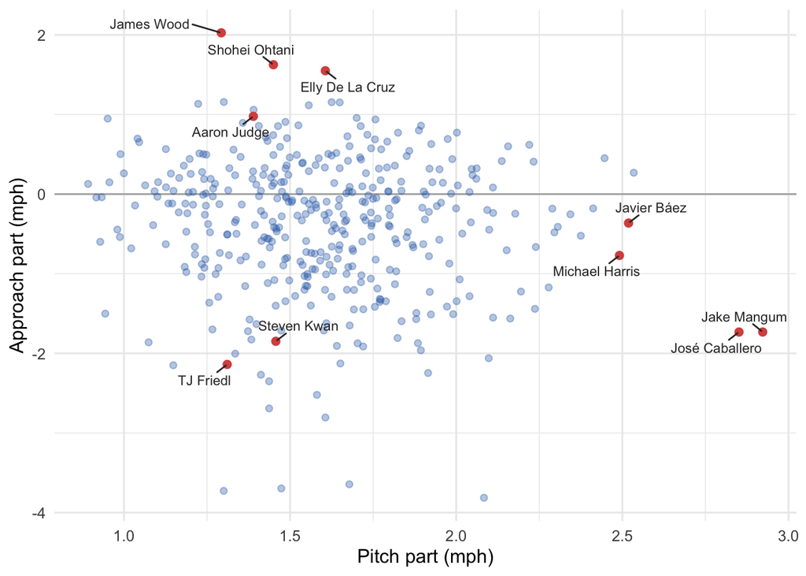

Figure 3: Each 2026 hitter’s estimated pitch part and approach part of his count effect. Labeled hitters are discussed below.

```r
show <- c("James Wood", "Shohei Ohtani", "Elly De La Cruz", "Aaron Judge",
          "Steven Kwan", "TJ Friedl", "Javier Báez", "José Caballero",
          "Jake Mangum", "Michael Harris")
lab_df <- filter(hitter_means, name %in% show)
ggplot(hitter_means, aes(Pitch, Approach)) +
  geom_hline(yintercept = 0, colour = "grey70") +
  geom_point(alpha = 0.35, colour = blue) +
  geom_point(data = lab_df, colour = red, size = 2) +
  ggrepel::geom_text_repel(data = lab_df, aes(label = name), size = 3,
                           colour = "grey20", min.segment.length = 0,
                           box.padding = 0.4, seed = 1) +
  labs(x = "Pitch part (mph)", y = "Approach part (mph)")
```

```r
chase <- pitches |>
  filter(zone %in% 11:14, batter %in% hitter_means$batter) |>
  mutate(swing = description %in% c("swinging_strike", "swinging_strike_blocked",
                                     "foul", "foul_tip", "hit_into_play",
                                     "foul_bunt", "missed_bunt", "bunt_foul_tip")) |>
  group_by(batter) |>
  summarise(chase = mean(swing), .groups = "drop")
hitter_means <- left_join(hitter_means, chase, by = "batter")

hitter_means |>
  filter(name %in% show) |>
  mutate(name = factor(name, levels = show)) |>
  arrange(name) |>
  transmute(Hitter = name, Total = f2(Total), `Pitch part` = f2(Pitch),
            `Approach part` = f2(Approach), `Chase rate` = pct(chase)) |>
  kable()
```

Table 6: Selected hitters: estimated total count effect and its parts (posterior means, mph), with 2026 chase rate

| Hitter | Total | Pitch part | Approach part | Chase rate |
| --- | --- | --- | --- | --- |
| James Wood | 3.32 | 1.29 | 2.03 | 21% |
| Shohei Ohtani | 2.87 | 1.45 | 1.63 | 30% |
| Elly De La Cruz | 2.92 | 1.61 | 1.55 | 25% |
| Aaron Judge | 2.13 | 1.39 | 0.98 | 26% |
| Steven Kwan | 0.03 | 1.46 | -1.85 | 20% |
| TJ Friedl | 0.08 | 1.31 | -2.14 | 24% |
| Javier Báez | 0.97 | 2.52 | -0.36 | 47% |
| José Caballero | 0.38 | 2.85 | -1.73 | 37% |
| Jake Mangum | 0.50 | 2.92 | -1.73 | 45% |
| Michael Harris | 0.97 | 2.49 | -0.77 | 45% |

The examples fall into three groups:

- **Power hitters** (Wood, Ohtani, De La Cruz, Judge) have ordinary pitch parts but large approach parts. Given the pitch, they hit the ball much less hard when behind. That is the easing-off pattern from the main study.
- **Contact hitters** (Kwan, Friedl) have ordinary pitch parts too, but strongly *negative* approach parts. Behind in the count they put the same sort of worse pitches in play, yet hit them harder than an average hitter would. Their small total count effects come from the swing, not from being pitched differently.
- **Free swingers** (Báez, Caballero, Mangum, Harris) have the largest pitch parts, as the friend suggested: behind in the count they put especially poor pitches in play. But for most of them the approach part is negative and partly offsets it, so their total count effects end up small to moderate.

The parts don’t add exactly to the total for each hitter. Each was estimated in a separate model, and each was shrunk by its own amount.

## Step 5: Does chasing explain the differences?

The friend’s specific hypothesis was about chasers: hitters who chase a lot might see unusual pitches when behind and put many poor ones in play. Chase rate here is the share of swings on 2026 pitches outside the strike zone (Statcast zones 11–14).

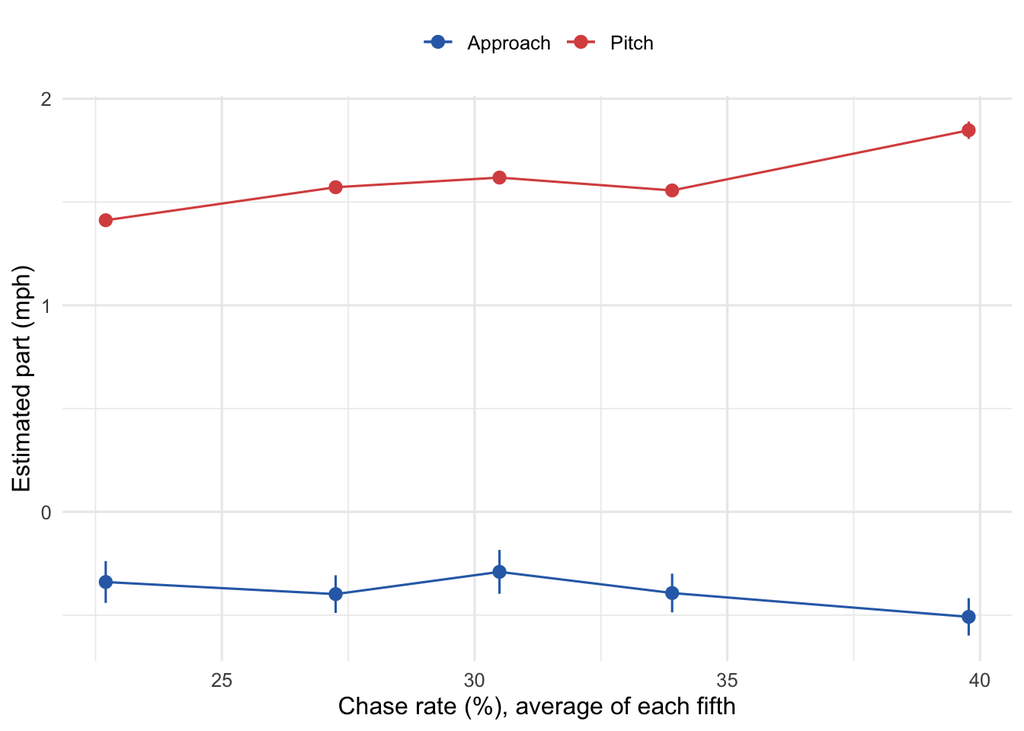

Figure 4: Hitters grouped into fifths by chase rate: average estimated pitch part and approach part of the count effect (±1 standard error)

```r
hitter_means |>
  mutate(fifth = ntile(chase, 5)) |>
  pivot_longer(c(Pitch, Approach), names_to = "Part") |>
  group_by(Part, fifth) |>
  summarise(x = mean(chase), y = mean(value), se = sd(value) / sqrt(n()),
            .groups = "drop") |>
  ggplot(aes(100 * x, y, colour = Part)) +
  geom_errorbar(aes(ymin = y - se, ymax = y + se), width = 0) +
  geom_line() + geom_point(size = 2.5) +
  scale_colour_manual(values = c(Approach = blue, Pitch = red), name = NULL) +
  labs(x = "Chase rate (%), average of each fifth", y = "Estimated part (mph)") +
  theme(legend.position = "top")
```

**The selection effect is real, but it lives in the pitch part.**

- **Chasers put worse pitches in play when behind.** Chase rate correlates 0.41 with the pitch part.
- **But not with the approach part.** The correlation there is -0.06.
- **So chasing barely relates to the total count effect** (-0.14).

Chasing changes which pitches a hitter puts in play when behind, but it isn’t what separates the hitters who lose the most exit velocity from those who lose the least.

## Step 6: A clean check with in-zone four-seamers

The expected-value approach relies on a model. A model-free check holds the pitch roughly fixed by using only **four-seam fastballs in the strike zone**. There are far fewer of these per hitter, so the threshold drops to 40 balls in play and estimates are shrunk more. For a fair comparison, the same hitters are also fit using all their balls in play.

```r
ff <- filter(bip, pitch_type == "FF", in_zone)
ff_ok <- count(ff, batter) |> filter(n >= 40) |> pull(batter)
ff_fit  <- fit_cells(make_cells(filter(ff, batter %in% ff_ok), "launch_speed"), 88, 61)
all_fit <- fit_cells(make_cells(filter(bip, batter %in% ff_ok), "launch_speed"), 88, 62)
```

```r
bind_rows(summ_row(all_fit, "All balls in play"),
          summ_row(ff_fit, "In-zone four-seamers only")) |>
  rename(Data = Part) |>
  mutate(Hitters = length(ff_ok), .after = Data) |>
  kable()
```

Table 7: Count effects for the same hitters from all balls in play and from in-zone four-seam fastballs only, 2026 (posterior means and 90% intervals, mph)

| Data | Hitters | Average effect β | Hitter spread τ_β | Correlation with level ρ | Divergences |
| --- | --- | --- | --- | --- | --- |
| All balls in play | 285 | 1.40 (1.21, 1.59) | 0.86 (0.58, 1.13) | 0.57 (0.35, 0.80) | 0 |
| In-zone four-seamers only | 285 | 0.87 (0.54, 1.18) | 0.90 (0.20, 1.53) | 0.32 (-0.06, 0.72) | 0 |

With the pitch held roughly fixed, the **average** count effect drops, as the split in Step 3 predicts. But the **spread across hitters stays about the same**, though with a much wider interval because there is far less data per hitter. This check uses no model of the pitch at all, and it agrees with the split: hitter differences are not an artifact of pitch mix.

## Caveats

- **Only balls in play.** Every comparison conditions on contact. The pitches a hitter swings at and misses, or takes, aren’t part of the exit-velocity data, so the pitch part describes which pitches end up *in play*, a mix of the pitcher’s choices and the hitter’s swing decisions.
- **The expected-value model is an average.** It predicts exit velocity for an average 2026 hitter. If some hitters handle certain pitches unusually well, part of that skill lands in their approach part.
- **Location isn’t everything.** The model uses pitch type, velocity, movement and location. Sequencing, deception and the hitter’s expectations aren’t measured.
- **The negative approach part needs care.** That balls in play when behind are hit slightly harder than expected may reflect which borderline pitches hitters choose to protect against with two strikes. It shouldn’t be read as hitters swinging *better* when behind.

## The bottom line

- **The average count effect is about the pitch.** Hitters lose exit velocity when behind mainly because more of their balls in play come on pitches outside the zone, which are hit softer in any count. Given the pitch, balls in play when behind are not hit softer.
- **The differences between hitters are about approach.** Nearly all the hitter-to-hitter spread, and the link between power and count effect, is in how hard hitters hit the pitches they put in play. That is where the main study’s results on easing off the swing apply.
- **Chasers are a pitch-part story.** Free swingers put especially poor pitches in play when behind, but that doesn’t decide who loses the most exit velocity.

The friend’s objection was well founded for the *average* count effect, and it changes how that average should be described. It does not undo the main finding that hitters genuinely differ in how much they lose when behind.